# Random_forest_classifier

```python
import numpy as np
import pandas as pd
import matplotlib.pyplot as plt
import seaborn as sns

from scipy import stats

from sklearn import metrics
from sklearn.metrics import log_loss,confusion_matrix
from sklearn.metrics import classification_report
from sklearn.preprocessing import StandardScaler, OneHotEncoder
from sklearn.model_selection import train_test_split
from sklearn.model_selection import cross_validate
from sklearn.model_selection import GridSearchCV, RandomizedSearchCV

from sklearn.linear_model import LogisticRegression
from sklearn.naive_bayes import GaussianNB
from sklearn.neighbors import KNeighborsClassifier
from sklearn.svm import SVC

from sklearn.tree import DecisionTreeClassifier
from sklearn.ensemble import BaggingClassifier
from sklearn.ensemble import AdaBoostClassifier
from sklearn.ensemble import GradientBoostingClassifier
from sklearn.ensemble import RandomForestClassifier
from xgboost import XGBClassifier

import warnings
warnings.filterwarnings('ignore')
```

```python
RS = 42
```

## Importing the dataset

```python
# /kaggle/input/heart-failure-prediction/heart.csv
data = pd.read_csv('heart.csv')
data.head()
```

|  | Age | Sex | ChestPainType | RestingBP | Cholesterol | FastingBS | RestingECG | MaxHR | ExerciseAngina | Oldpeak | ST_Slope | HeartDisease |
| --- | --- | --- | --- | --- | --- | --- | --- | --- | --- | --- | --- | --- |
| 0 | 40 | M | ATA | 140 | 289 | 0 | Normal | 172 | N | 0.0 | Up | 0 |
| 1 | 49 | F | NAP | 160 | 180 | 0 | Normal | 156 | N | 1.0 | Flat | 1 |
| 2 | 37 | M | ATA | 130 | 283 | 0 | ST | 98 | N | 0.0 | Up | 0 |
| 3 | 48 | F | ASY | 138 | 214 | 0 | Normal | 108 | Y | 1.5 | Flat | 1 |
| 4 | 54 | M | NAP | 150 | 195 | 0 | Normal | 122 | N | 0.0 | Up | 0 |

```python
data.shape
```

```
(918, 12)
```

### Train-test split

```python
X = data.drop('HeartDisease', axis = 1)
Y = data['HeartDisease']

X_train, X_test, y_train, y_test = train_test_split(X, Y, random_state = RS, test_size = 0.10, stratify = Y)
```

```python
X_train.shape, X_test.shape, y_train.shape, y_test.shape
```

```
((826, 11), (92, 11), (826,), (92,))
```

```python
df = X_train.join(y_train, how = 'inner')
df.sort_index(axis = 0, inplace = True)
```

```python
df.shape
```

```
(826, 12)
```

## Data Cleansing

### Information about dataset

```python
df.info()
```

```
<class 'pandas.core.frame.DataFrame'>
Int64Index: 826 entries, 0 to 916
Data columns (total 12 columns):
 #   Column          Non-Null Count  Dtype
---  ------          --------------  -----
 0   Age             826 non-null    int64
 1   Sex             826 non-null    object
 2   ChestPainType   826 non-null    object
 3   RestingBP       826 non-null    int64
 4   Cholesterol     826 non-null    int64
 5   FastingBS       826 non-null    int64
 6   RestingECG      826 non-null    object
 7   MaxHR           826 non-null    int64
 8   ExerciseAngina  826 non-null    object
 9   Oldpeak         826 non-null    float64
 10  ST_Slope        826 non-null    object
 11  HeartDisease    826 non-null    int64
dtypes: float64(1), int64(6), object(5)
memory usage: 83.9+ KB
```

```python
df['FastingBS'].value_counts(), df['HeartDisease'].value_counts()
```

```
(0    637
 1    189
 Name: FastingBS, dtype: int64,
 1    457
 0    369
 Name: HeartDisease, dtype: int64)
```

There are no NULL values in the dataset.

'FastingBS' and 'HeartDisease' have only two values, so let us change them to categorial datatype for better analysis . Otherthan that all the other features seems to have their corresponding datatypes.

Numerical features are correctly defined with their respective datatypes, So there is no possiblity for improper/special characters in Numerical features. (But we have to check for improper/special characters in Categorical features- which we will be doing in upcoming codes)

**Changing the FastingBS from int64 to object/Categorical**

```python
df['FastingBS']=df['FastingBS'].astype('category')
```

**Checking for Duplicate entries in the dataset**

```python
Duplicate = df[df.duplicated(keep='first')]

print("Duplicate Entries :")

Duplicate.shape
```

```
Duplicate Entries :
```

```
(0, 12)
```

There are no duplicate entries in the dataset

**Segregating categorical features and numerical features**

```python
num_cols=df.select_dtypes(include=['int64','float64']).columns.tolist()

cat_cols=df.select_dtypes(include=['category','object']).columns.tolist()
```

```python
print(num_cols)
print(cat_cols)
```

```
['Age', 'RestingBP', 'Cholesterol', 'MaxHR', 'Oldpeak', 'HeartDisease']
['Sex', 'ChestPainType', 'FastingBS', 'RestingECG', 'ExerciseAngina', 'ST_Slope']
```

**Checking for Values in each categorical feature and looking for any special/improper characters**

```python
for i in cat_cols:
     print("{} : {} ".format(i,df[i].unique()))
```

```
Sex : ['M' 'F']
ChestPainType : ['ATA' 'ASY' 'NAP' 'TA']
FastingBS : [0, 1]
Categories (2, int64): [0, 1]
RestingECG : ['Normal' 'ST' 'LVH']
ExerciseAngina : ['N' 'Y']
ST_Slope : ['Up' 'Flat' 'Down']
```

There are no special/improper characters present in categorical features

## Data analysis and visualization

### 5 point summary

```python
df.describe().T
```

|  | count | mean | std | min | 25% | 50% | 75% | max |
| --- | --- | --- | --- | --- | --- | --- | --- | --- |
| Age | 826.0 | 53.716707 | 9.395144 | 28.0 | 47.0 | 54.0 | 60.00 | 77.0 |
| RestingBP | 826.0 | 132.506053 | 18.667829 | 0.0 | 120.0 | 130.0 | 140.00 | 200.0 |
| Cholesterol | 826.0 | 201.684019 | 107.990923 | 0.0 | 177.0 | 223.5 | 268.00 | 603.0 |
| MaxHR | 826.0 | 136.377724 | 25.825666 | 60.0 | 119.0 | 138.0 | 155.75 | 202.0 |
| Oldpeak | 826.0 | 0.868644 | 1.056614 | -2.6 | 0.0 | 0.5 | 1.50 | 5.6 |
| HeartDisease | 826.0 | 0.553269 | 0.497456 | 0.0 | 0.0 | 1.0 | 1.00 | 1.0 |

*Insights*

*We can check for skewness in the dataset by the following way*

```python
from scipy.stats import shapiro

for feature in num_cols:
    data = df.copy()
    DataToTest = data[feature]
    stat, p = shapiro(DataToTest)
    print(feature)
    print('stat = %.2f, p = %.30f' % (stat, p))

    if p > 0.05:
        print('Normal distribution')
        print()
    else:
        print('Not a normal distribution')
        print()
```

```
Age
stat = 0.99, p = 0.000023468859581043943762779236
Not a normal distribution

RestingBP
stat = 0.95, p = 0.000000000000002975722458427397
Not a normal distribution

Cholesterol
stat = 0.87, p = 0.000000000000000000000000141255
Not a normal distribution

MaxHR
stat = 0.99, p = 0.000289700547000393271446228027
Not a normal distribution

Oldpeak
stat = 0.86, p = 0.000000000000000000000000017517
Not a normal distribution

HeartDisease
stat = 0.63, p = 0.000000000000000000000000000000
Not a normal distribution
```

None of the features are normally distributed. We need to make these features normally distributed before building the model by applying some Tranformations(FEATURE ENGINEERING)

### Univariate analysis

*Univariate analysis on numerical features*

```
 AGE
```

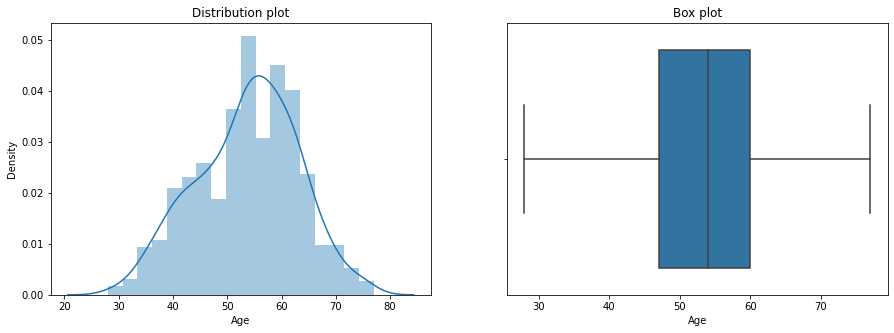

```
Total number of outliers in Age: 0
Percentage of outliers in Age: 0.0 %


 RESTINGBP
```

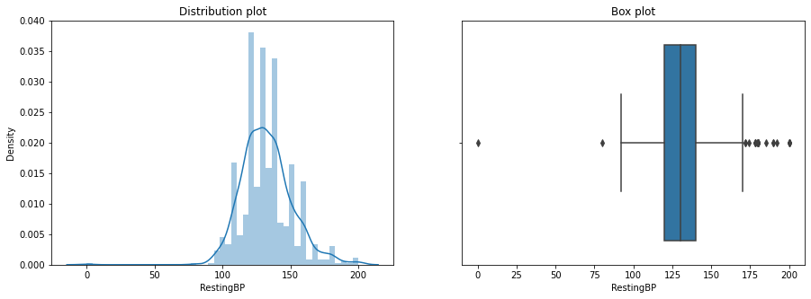

```
Total number of outliers in RestingBP: 27
Percentage of outliers in RestingBP: 3.27 %


 CHOLESTEROL
```

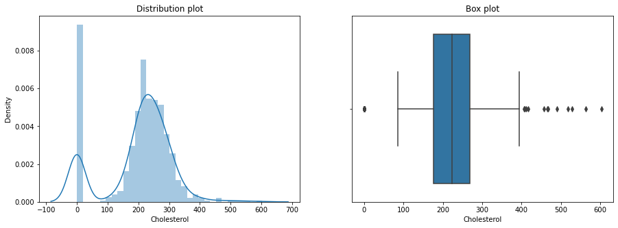

```
Total number of outliers in Cholesterol: 158
Percentage of outliers in Cholesterol: 19.13 %


 MAXHR
```

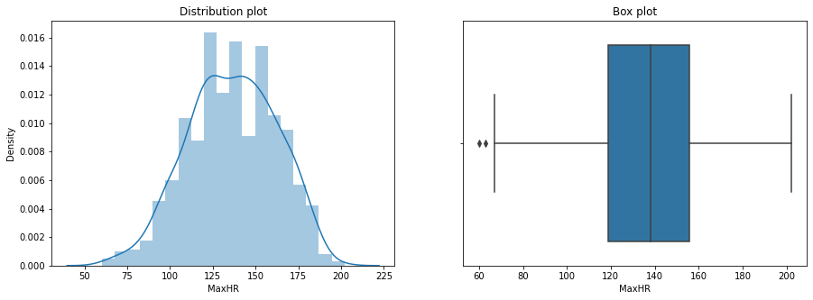

```
Total number of outliers in MaxHR: 2
Percentage of outliers in MaxHR: 0.24 %


 OLDPEAK
```

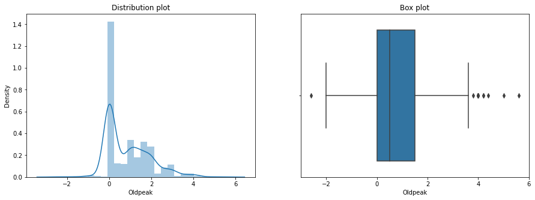

```
Total number of outliers in Oldpeak: 15
Percentage of outliers in Oldpeak: 1.82 %


 HEARTDISEASE
```

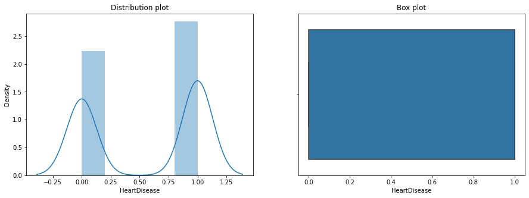

```
Total number of outliers in HeartDisease: 0
Percentage of outliers in HeartDisease: 0.0 %
```

```python
for i in num_cols:
    print('{} \n\n {}'.format('\033[1m',i.upper()))
    f, axes = plt.subplots(1, 2, figsize=(15,5))
    sns.boxplot(x = i, data=df,  orient='h' , ax=axes[1])
    sns.distplot(df[i],  ax=axes[0])
    axes[0].set_title('Distribution plot')
    axes[1].set_title('Box plot')
    plt.show()


    q25,q75=np.percentile(df[i],25),np.percentile(df[i],75)
    IQR=q75-q25
    Threshold=IQR*1.5
    lower,upper=q25-Threshold,q75+Threshold
    Outliers=[i for i in df[i] if i<lower or i>upper]
    print('Total number of outliers in {}: {}'.format(i,len(Outliers)))
    percent=round((len(Outliers)/len(df[i]))*100,2)
    print('Percentage of outliers in {}: {} %'.format(i,percent))
```

*Insights*

- There are some outliers in the dataset, we need to handle them before building the model or we should use the models that are robust to outliers.
- Also we can see that cholestrol level of some people is zero, which should be handled before building the model because cholestrol levels can never be zero this maybe because of some human errors.

*Univariate analysis on categorical features*

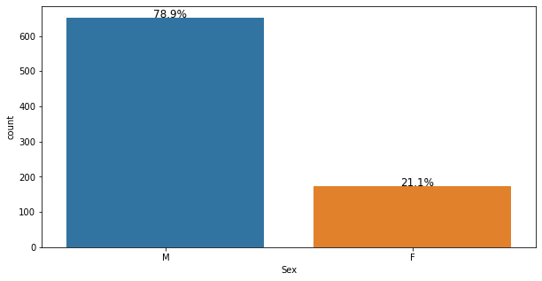

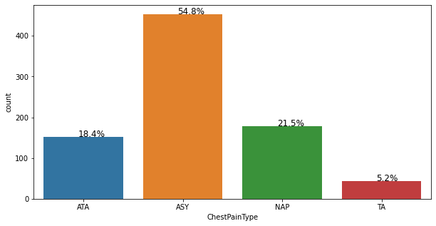

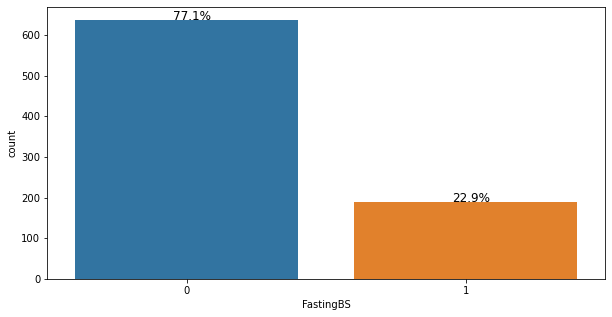

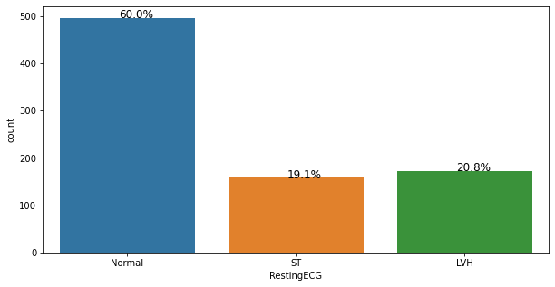

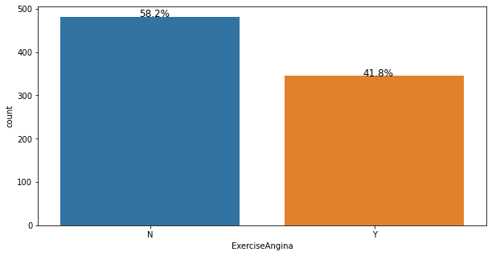

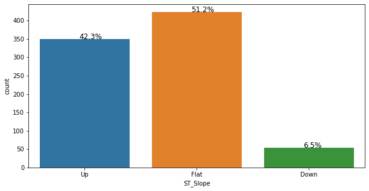

```python
for i in cat_cols:
    plt.figure(figsize=(10,5))
    plot=sns.countplot(df[i])

    total = len(df[i])
    for p in plot.patches:
        percentage = '{:.1f}%'.format(100 * p.get_height()/total)
        x = p.get_x() + p.get_width() / 2 - 0.05
        y = p.get_y() + p.get_height()
        plot.annotate(percentage, (x, y), size = 12)

    plt.show()
```

*Insights*

- **Sex** - Distribution of male is more when compared to female distribution
- **ChestPainType** - Majority of the people have chest pain of the type "ASY"
- **FastingBS** - About 77.1% of people have fastingBS<120 mg/dl
- **RestingECG** - Majority of them have restingECG as normal, while about 40% have abnormal restingECG
- **ExerciseAngina** - 41.8% of the people have exercise-induced angina
- **ST_Slope** - Half of the people have flat slope while 42.3% have Up slope and the remaining have down slope
- **HeartDisease** - 55.3% of the the people are found to have heart disease

### Bivariate Analysis

*Numerical variables vs Target variable*

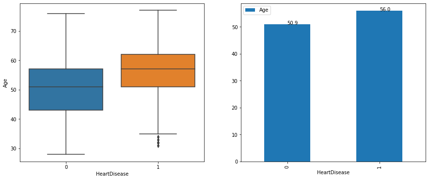

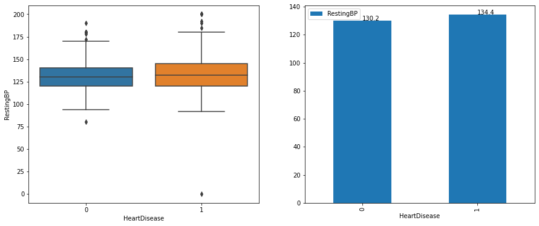

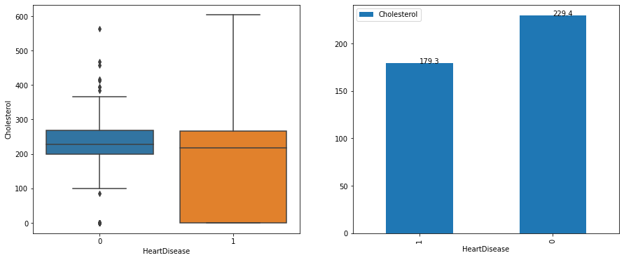

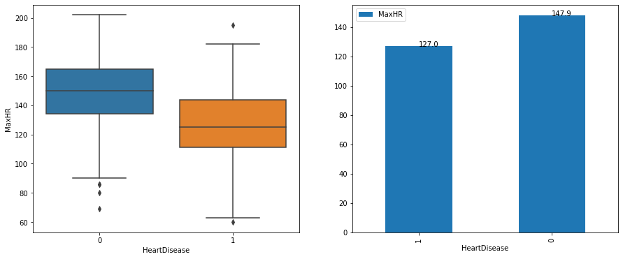

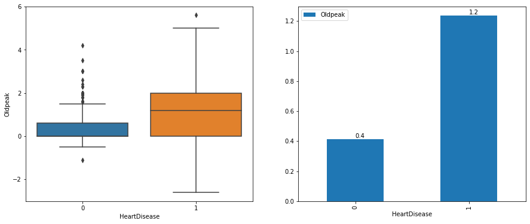

```python
for i in num_cols:
    if i != 'HeartDisease':
        f,axes=plt.subplots(1,2,figsize=(15,6))
        sns.boxplot(x='HeartDisease', y=i, data= df, ax=axes[0])
        ax=df.groupby(by=['HeartDisease'])[i].mean().reset_index().sort_values(i,ascending=True).plot(x='HeartDisease',y=i,kind='bar',ax=axes[1])

        for p in ax.patches:
            ax.annotate('{:.1f}'.format(p.get_height()), (p.get_x()+0.25, p.get_height()+0.01))
```

*Categorical variable vs Target variable*

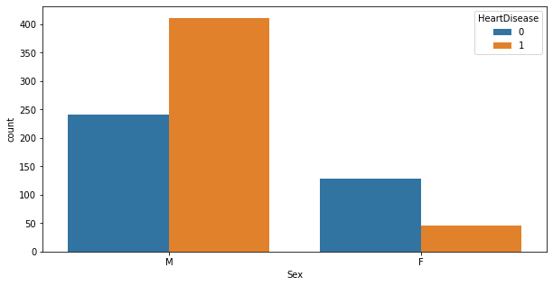

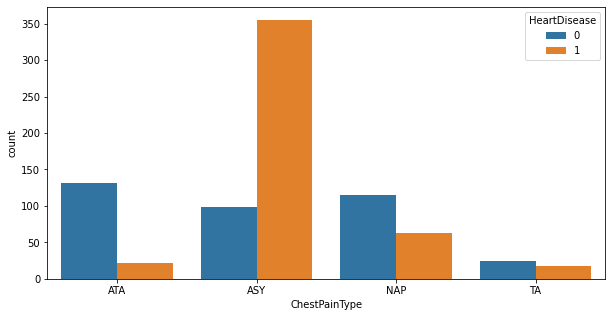

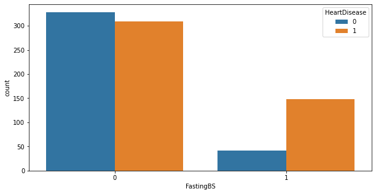

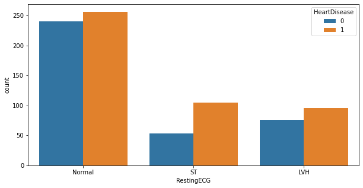

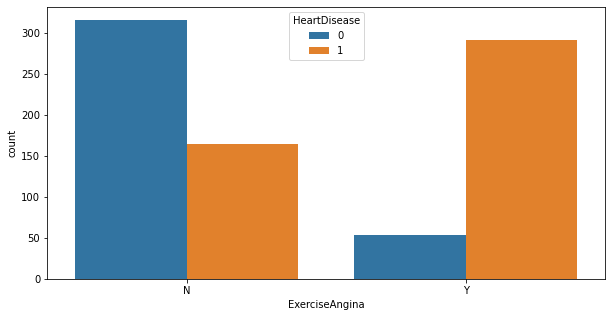

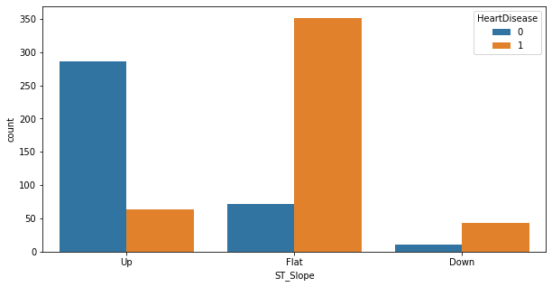

```python
for i in cat_cols:
    if i!='HeartDisease':
        plt.figure(figsize=(10,5))
        sns.countplot(df[i],hue=df['HeartDisease'])
        plt.show()
```

*Insights*

- **Sex** - Male have high risk of being affected by heart disease when compared to female
- **ChestPainType** - ChestPainType-ASY indicates that the patient is highly prone to heart disease
- **FastingBS** - fasting blood sugar [1: if FastingBS > 120 mg/dl, 0: otherwise] - People with FastingBS 1 have chances of being affected by heart disease
- **RestingECG** - RestingECG does not provide any clear conclusion on heartdisease
- **ExerciseAngina** - People with exercise-induced angina have chances of being affected by heart disease
- **ST_Solpe** - People with flat ST_Slope have heart disease

*Multivariate analysis*

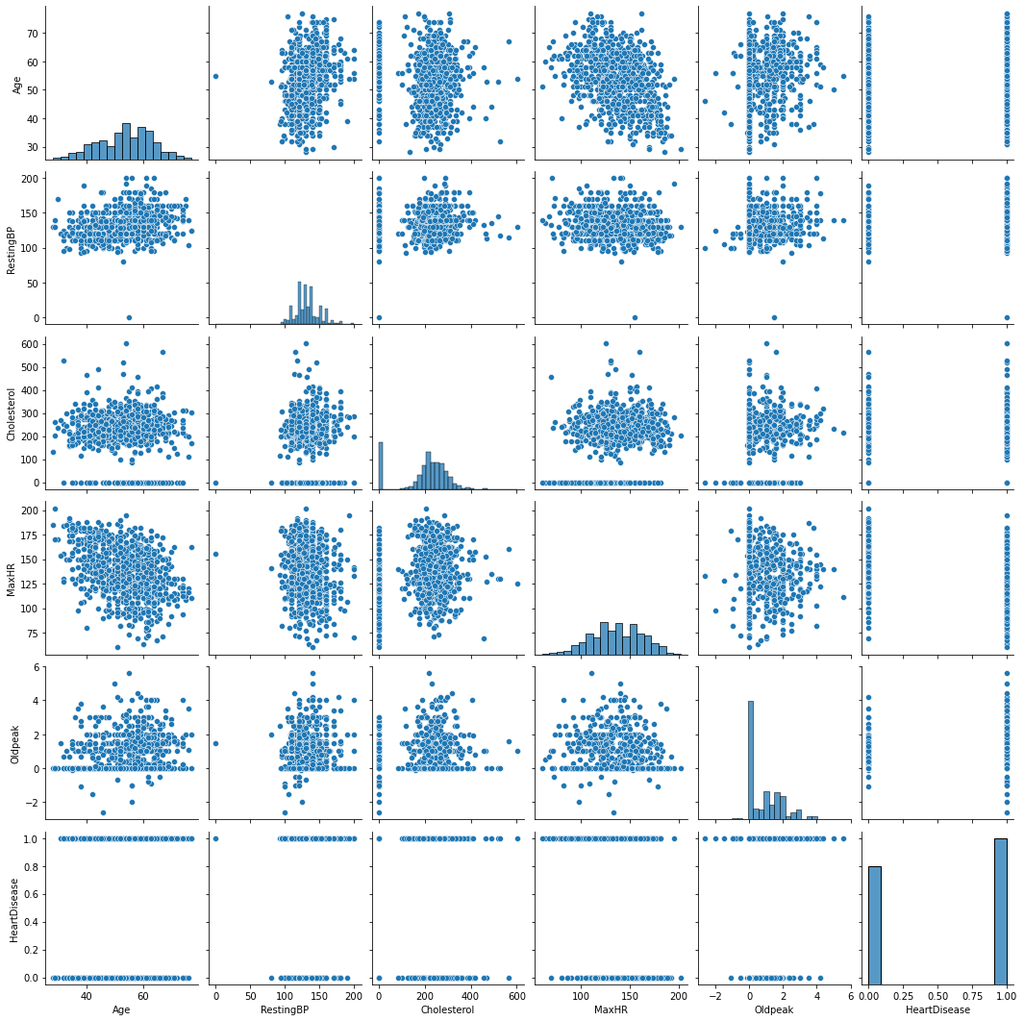

```python
sns.pairplot(df);
```

*Insights*

- Cholesterol and RestingBP with value 0 should be handled before building the model

*Correlation heatmap*

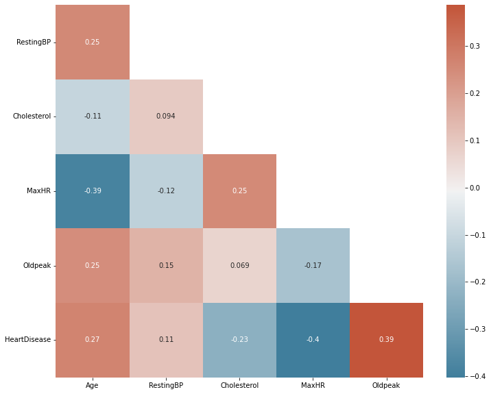

```python
corr = df.corr()
f, ax = plt.subplots(figsize=(12, 10))
mask = np.triu(np.ones_like(corr, dtype=bool))[1:, :-1]
corr = corr.iloc[1:,:-1].copy()
cmap = sns.diverging_palette(230, 20, as_cmap=True)
sns.heatmap(corr, annot=True, mask = mask, cmap=cmap)
plt.yticks(rotation=0)
plt.show()
```

Almost all the input features are fairly independent of each other

## FEATURE ENGINEERING

```python
X_train_final, X_validation, y_train_final, y_validation = train_test_split(X_train, y_train,  random_state = RS, test_size = 0.20, stratify = y_train)
X_train_final.shape, X_validation.shape
```

```
((660, 11), (166, 11))
```

*One hot encoding*

```python
X_train_ohe = pd.get_dummies(X_train_final[cat_cols], drop_first = True)
X_validation_ohe = pd.get_dummies(X_validation[cat_cols], drop_first = True)
```

```python
X_train_ohe.shape, X_validation_ohe.shape
```

```
((660, 10), (166, 10))
```

*Scaling the data*

```python
cols_to_scale = ['Age', 'RestingBP', 'Cholesterol', 'MaxHR', 'Oldpeak']

scaler = StandardScaler()
X_train_scale = pd.DataFrame(index = X_train_final.index)
X_validation_scale = pd.DataFrame(index = X_validation.index)
X_train_scale[cols_to_scale] = scaler.fit_transform(X_train_final[cols_to_scale])
X_validation_scale[cols_to_scale] = scaler.transform(X_validation[cols_to_scale])
```

```python
X_train_scale.shape, X_validation_scale.shape
```

```
((660, 5), (166, 5))
```

*Concatenating One hot encoded features and Scaled features*

```python
X_train_fe = pd.concat([X_train_scale, X_train_ohe], axis = 1)
X_validation_fe = pd.concat([X_validation_scale, X_validation_ohe], axis = 1)
```

```python
X_train_fe.shape, y_train_final.shape, X_validation_fe.shape, y_validation.shape
```

```
((660, 15), (660,), (166, 15), (166,))
```

```python
from sklearn.impute import SimpleImputer

to_transform = ['Cholesterol', 'RestingBP']
imp_median = SimpleImputer(missing_values = 0, strategy = 'median')
X_train_fe[to_transform] = imp_median.fit_transform(X_train_fe[to_transform])
X_validation_fe[to_transform] = imp_median.transform(X_validation_fe[to_transform])
```

## FEATURE SELECTION

*Checking for constant, quasi constant features*

```python
from sklearn.feature_selection import VarianceThreshold

constant_filter = VarianceThreshold(threshold = 0.01)
constant_filter.fit(X_train_fe)
```

```
VarianceThreshold(threshold=0.01)
```

```python
constant_filter.get_support().sum()
```

```
15
```

There are no constant and quasi constant features in the dataset.

*Checking for duplicate features*

```python
X_train_T = X_train_fe.T
X_train_T.duplicated().sum()
```

```
0
```

There are no duplicate features in the dataset

*Checking for multicollinearity*

```
<BarContainer object of 7 artists>
```

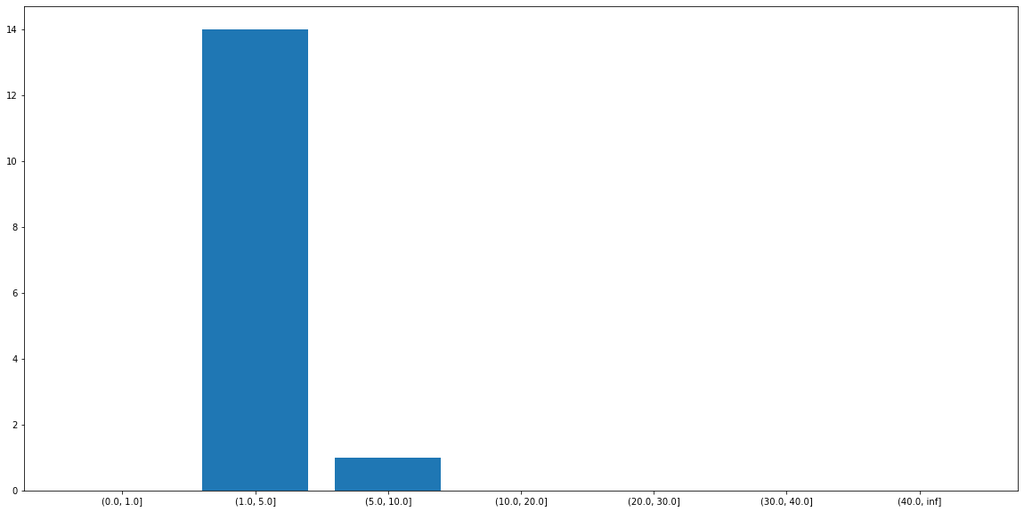

```python
df = X_train_fe.copy()
vif = pd.Series(np.linalg.inv(df.corr().values).diagonal(),index=df.columns,
          name='VIF').abs().sort_values(ascending=False).round(2)
df = pd.cut(vif.round(1),[0,1,5,10,20,30,40,float('inf')]).value_counts().sort_index()
df.index = df.index.map(str)

plt.subplots(figsize=(20, 10))
plt.bar(x=df.index, height=df)
```

- Generally VIF > 10 is considered as high, None of the features have VIF value greater than 10.

*Feature selection by Recursive Feature Elimination with cross-validation*

```python
from sklearn.feature_selection import RFECV
from sklearn.model_selection import StratifiedKFold

skf = StratifiedKFold(n_splits=5, random_state = RS, shuffle=True)
sel = RFECV(RandomForestClassifier(n_estimators = 100, random_state = RS, n_jobs = -1), cv = skf)
sel.fit(X_train_fe, y_train_final)
```

```
RFECV(cv=StratifiedKFold(n_splits=5, random_state=42, shuffle=True),
      estimator=RandomForestClassifier(n_jobs=-1, random_state=42))
```

```python
print('Optimal number of features: {}'.format(sel.n_features_))
```

```
Optimal number of features: 11
```

```python
sel.get_support()
```

```
array([ True,  True,  True,  True,  True, False,  True,  True,  True,
       False, False, False,  True,  True,  True])
```

```python
features = X_train_fe.columns[sel.get_support()]
features
```

```
Index(['Age', 'RestingBP', 'Cholesterol', 'MaxHR', 'Oldpeak', 'Sex_M',
       'ChestPainType_ATA', 'ChestPainType_NAP', 'ExerciseAngina_Y',
       'ST_Slope_Flat', 'ST_Slope_Up'],
      dtype='object')
```

Only these features contribute in predicting.

```python
X_train_sel = pd.DataFrame(sel.transform(X_train_fe), columns = features)
X_train_sel.shape, y_train_final.shape
```

```
((660, 11), (660,))
```

*Checking for Target Imbalance*

```python
y_train_final.value_counts()
```

```
1    365
0    295
Name: HeartDisease, dtype: int64
```

Our dataset is imbalanced

```python
from imblearn.over_sampling import SMOTE
oversample = SMOTE(random_state = RS)
X_train_upsampled, y_train_upsampled = oversample.fit_resample(X_train_sel, y_train_final)
```

```python
X_train_upsampled.shape, y_train_upsampled.shape
```

```
((730, 11), (730,))
```

```python
X_validation_sel = pd.DataFrame(sel.transform(X_validation_fe), columns = features)
X_validation_sel.shape, y_validation.shape
```

```
((166, 11), (166,))
```

## MODEL BUILDING

```python
scorer = {
    'accuracy' : metrics.make_scorer(metrics.accuracy_score),
    'precision' : metrics.make_scorer(metrics.precision_score),
    'recall' : metrics.make_scorer(metrics.recall_score),
    'f1' : metrics.make_scorer(metrics.f1_score),
    'loss' : metrics.make_scorer(metrics.log_loss)
}
```

```python
import time
```

```python
def fit_models(model, X_train, X_test, y_train, y_test):

    start = time.time()

    model.fit(X_train, y_train)
    pred = model.predict(X_test)

    accuracy = metrics.accuracy_score(y_test,pred)
    precision = metrics.precision_score(y_test,pred)
    recall = metrics.recall_score(y_test,pred)
    f1 = metrics.f1_score(y_test,pred)
    loss = metrics.log_loss(y_test,pred)

    scorer = {
    'accuracy' : metrics.make_scorer(metrics.accuracy_score),
    'precision' : metrics.make_scorer(metrics.precision_score),
    'recall' : metrics.make_scorer(metrics.recall_score),
    'f1' : metrics.make_scorer(metrics.f1_score),
    'loss' : metrics.make_scorer(metrics.log_loss)
    }

    cv = cross_validate(estimator = model, X = X_train, y = y_train, cv=10, scoring = scorer)

    accuracy_cv = cv['test_accuracy'].mean()
    precision_cv = cv['test_precision'].mean()
    recall_cv = cv['test_recall'].mean()
    f1_cv = cv['test_f1'].mean()
    loss_cv = cv['test_loss'].mean()

    end = time.time()  #note the end time
    duration = end - start  # calculate the total duration

    return f1, accuracy, precision, recall, loss, f1_cv, accuracy_cv, precision_cv, recall_cv, loss_cv, duration
```

```python
lr = LogisticRegression(random_state = RS)
gnb = GaussianNB()
knn = KNeighborsClassifier()
svm = SVC(random_state = RS)
dT_gini = DecisionTreeClassifier(random_state = RS)
dT_entropy = DecisionTreeClassifier(random_state = RS)
bgcl = BaggingClassifier(n_estimators=100,random_state = RS)
abcl = AdaBoostClassifier(n_estimators=100, random_state = RS)
gbcl = GradientBoostingClassifier(n_estimators = 100,random_state = RS)
rfcl = RandomForestClassifier(n_estimators = 100, random_state = RS)
xgbcl = XGBClassifier(n_estimators = 100, random_state = RS, eval_metric = 'logloss')

result = {}

for model,name in zip([lr, gnb, knn, svm, dT_gini, dT_entropy, bgcl, abcl, gbcl, rfcl, xgbcl],
                     ['Logistic Regression', 'Gaussian NB', 'KNN', 'SVC', 'Decision Tree(gini)',
                     'Decision Tree(entropy)', 'Bagging Classifier', 'Adaptive Boosting',
                      'Gradient Boosting', 'Random Forest Classifier', 'XGB Classifier']):
    result[name] = fit_models(model,X_train_upsampled, X_validation_sel, y_train_upsampled, y_validation)
```

```python
result1 = pd.DataFrame(np.array(list(result.values())),    # make a dataframe out of the metrics from result dictionary
                       columns= ['F1-SCORE', 'ACCURACY', 'PRECISION', 'RECALL', 'LOG LOSS', 'F1_SCORE(CV)', 'ACCURACY(CV)',
                                'PRECISION(CV)', 'RECALL(CV)',  'LOG LOSS(CV)', 'DURATION'],
                       index= result.keys())   # use the model names as index

result1.index.name = 'Model'   # name the index of the result1 dataframe as 'Model'

result1
```

| Model | F1-SCORE | ACCURACY | PRECISION | RECALL | LOG LOSS | F1_SCORE(CV) | ACCURACY(CV) | PRECISION(CV) | RECALL(CV) | LOG LOSS(CV) | DURATION |
| --- | --- | --- | --- | --- | --- | --- | --- | --- | --- | --- | --- |
| Logistic Regression | 0.902174 | 0.891566 | 0.902174 | 0.902174 | 3.745212 | 0.840353 | 0.838356 | 0.830789 | 0.852327 | 5.583050 | 0.116663 |
| Gaussian NB | 0.913978 | 0.903614 | 0.904255 | 0.923913 | 3.329082 | 0.850129 | 0.846575 | 0.831566 | 0.871396 | 5.299171 | 0.062443 |
| KNN | 0.908108 | 0.897590 | 0.903226 | 0.913043 | 3.537147 | 0.853712 | 0.850685 | 0.841836 | 0.868994 | 5.157227 | 0.093729 |
| SVC | 0.924731 | 0.915663 | 0.914894 | 0.934783 | 2.912947 | 0.857623 | 0.850685 | 0.821919 | 0.898874 | 5.157239 | 0.187117 |
| Decision Tree(gini) | 0.864865 | 0.849398 | 0.860215 | 0.869565 | 5.201686 | 0.755569 | 0.757534 | 0.774128 | 0.745721 | 8.374562 | 0.062485 |
| Decision Tree(entropy) | 0.864865 | 0.849398 | 0.860215 | 0.869565 | 5.201686 | 0.755569 | 0.757534 | 0.774128 | 0.745721 | 8.374562 | 0.078107 |
| Bagging Classifier | 0.907104 | 0.897590 | 0.912088 | 0.902174 | 3.537142 | 0.834285 | 0.830137 | 0.823357 | 0.852402 | 5.866937 | 2.090405 |
| Adaptive Boosting | 0.896175 | 0.885542 | 0.901099 | 0.891304 | 3.953277 | 0.839839 | 0.839726 | 0.836740 | 0.846547 | 5.535734 | 1.366403 |
| Gradient Boosting | 0.923913 | 0.915663 | 0.923913 | 0.923913 | 2.912943 | 0.837726 | 0.836986 | 0.835195 | 0.844219 | 5.630362 | 0.969096 |
| Random Forest Classifier | 0.923913 | 0.915663 | 0.923913 | 0.923913 | 2.912943 | 0.849679 | 0.846575 | 0.836834 | 0.868694 | 5.299170 | 1.359496 |
| XGB Classifier | 0.919786 | 0.909639 | 0.905263 | 0.934783 | 3.121017 | 0.829325 | 0.827397 | 0.827649 | 0.835511 | 5.961560 | 1.046731 |

### Model evaluation function

```python
from sklearn.metrics import precision_recall_curve
from sklearn.metrics import f1_score
from sklearn.metrics import auc
from sklearn.metrics import log_loss
from sklearn.metrics import precision_recall_curve, roc_auc_score, auc, roc_curve

def evaluation(clf, X, y):
    pred = clf.predict(X)
    y_predict_proba = clf.predict_proba(X)[:, 1]

    precision, recall, thresholds = precision_recall_curve(y, y_predict_proba)
    fpr, tpr, thresholds = roc_curve(y, y_predict_proba)
    f1 = f1_score(y, pred)
    loss = log_loss(y, pred)

    return{
        'ROC AUC': auc(fpr, tpr), # Alternatively: roc_auc_score(y, y_predict_proba)
        'PRECISION-RECALL AUC': auc(recall, precision), # Alternatively (with slight difference): average_precision_score(y, y_predict_proba)
        'F1-SCORE': f1,
        'LOSS': loss
    }
```

## RANDOM FOREST CLASSIFIER

```python
rfcl.score(X_train_upsampled, y_train_upsampled)
```

```
1.0
```

- Random forest classifier is overfitting.
- We need to tune our hyperparameters to reduce overfitting.(Hyperparameter tuning is one of the many ways to reduce overfitting)

*Random Forest Classifier Hyperparameter tuning*

```python
params = {'bootstrap': [True, False],
          'max_depth': [10, 20, 30, 40, 50, 60, 70, 80, 90, 100, None],
          'max_features': ['auto', 'sqrt'],
          'min_samples_leaf': [1, 2, 4],
          'min_samples_split': [2, 5, 10],
          'n_estimators': [200, 400, 600, 800, 1000]}
```

```python
rf_clf_hp = RandomForestClassifier()

rs_rf = RandomizedSearchCV(estimator = rf_clf_hp, param_distributions = params, n_iter = 100, cv = skf, random_state=RS, n_jobs = -1)
rs_rf.fit(X_train_upsampled, y_train_upsampled)
```

```
RandomizedSearchCV(cv=StratifiedKFold(n_splits=5, random_state=42, shuffle=True),
                   estimator=RandomForestClassifier(), n_iter=100, n_jobs=-1,
                   param_distributions={'bootstrap': [True, False],
                                        'max_depth': [10, 20, 30, 40, 50, 60,
                                                      70, 80, 90, 100, None],
                                        'max_features': ['auto', 'sqrt'],
                                        'min_samples_leaf': [1, 2, 4],
                                        'min_samples_split': [2, 5, 10],
                                        'n_estimators': [200, 400, 600, 800,
                                                         1000]},
                   random_state=42)
```

```python
rs_rf.best_params_
```

```
{'n_estimators': 400,
 'min_samples_split': 10,
 'min_samples_leaf': 4,
 'max_features': 'auto',
 'max_depth': 30,
 'bootstrap': False}
```

```python
rf_clf_hp = RandomForestClassifier(**rs_rf.best_params_)
rf_clf_hp.fit(X_train_upsampled, y_train_upsampled)
```

```
RandomForestClassifier(bootstrap=False, max_depth=30, min_samples_leaf=4,
                       min_samples_split=10, n_estimators=400)
```

```python
rf_clf_hp.score(X_train_upsampled, y_train_upsampled)
```

```
0.9452054794520548
```

### PREDICTION ON VALIDATION DATA

```python
pred = rf_clf_hp.predict(X_validation_sel)
report = pd.DataFrame(classification_report(y_validation, pred, output_dict=True)).T
report
```

|  | precision | recall | f1-score | support |
| --- | --- | --- | --- | --- |
| 0 | 0.907895 | 0.932432 | 0.920000 | 74.000000 |
| 1 | 0.944444 | 0.923913 | 0.934066 | 92.000000 |
| accuracy | 0.927711 | 0.927711 | 0.927711 | 0.927711 |
| macro avg | 0.926170 | 0.928173 | 0.927033 | 166.000000 |
| weighted avg | 0.928151 | 0.927711 | 0.927796 | 166.000000 |

Overfitting is reduced to an extent

### Model evaluation

```python
evaluation(rf_clf_hp, X_validation_sel, y_validation)
```

```
{'ROC AUC': 0.9763513513513513,
 'PRECISION-RECALL AUC': 0.9830645197158874,
 'F1-SCORE': 0.934065934065934,
 'LOSS': 2.4968031007595135}
```

### PREDICTION ON TEST DATA

```python
X_test.shape, y_test.shape
```

```
((92, 11), (92,))
```

*One hot encoding*

```python
X_test_ohe = pd.get_dummies(X_test[cat_cols], drop_first = True)
X_test_ohe.head()
```

|  | FastingBS | Sex_M | ChestPainType_ATA | ChestPainType_NAP | ChestPainType_TA | RestingECG_Normal | RestingECG_ST | ExerciseAngina_Y | ST_Slope_Flat | ST_Slope_Up |
| --- | --- | --- | --- | --- | --- | --- | --- | --- | --- | --- |
| 489 | 0 | 1 | 0 | 0 | 0 | 1 | 0 | 1 | 1 | 0 |
| 337 | 1 | 1 | 0 | 0 | 0 | 0 | 1 | 0 | 0 | 1 |
| 481 | 1 | 1 | 0 | 1 | 0 | 0 | 1 | 0 | 0 | 0 |
| 821 | 0 | 0 | 0 | 1 | 0 | 1 | 0 | 0 | 0 | 1 |
| 83 | 0 | 1 | 1 | 0 | 0 | 1 | 0 | 0 | 0 | 1 |

*Scaling the data*

```python
X_test_scale = pd.DataFrame(index = X_test.index)
X_test_scale[cols_to_scale] = scaler.transform(X_test[cols_to_scale])
X_test_scale.head()
```

|  | Age | RestingBP | Cholesterol | MaxHR | Oldpeak |
| --- | --- | --- | --- | --- | --- |
| 489 | 0.029845 | 0.207026 | 0.135539 | 0.121544 | 1.997037 |
| 337 | 0.977874 | 0.954847 | -1.886474 | 0.669382 | 2.662813 |
| 481 | 1.609894 | 0.420689 | -1.886474 | -0.739344 | 1.521484 |
| 821 | 0.661865 | -1.609109 | 1.036254 | 0.904170 | -0.856285 |
| 83 | -0.180828 | 1.489004 | -0.085044 | 1.099826 | -0.856285 |

*Concatenating One hot encoded features and Scaled features*

```python
X_test_new = pd.concat([X_test_scale, X_test_ohe], axis = 1)
X_test_new.shape, y_test.shape
```

```
((92, 15), (92,))
```

*Replacing 0 with median in Cholesterol and RestingBP*

```python
X_test_new[to_transform] = imp_median.transform(X_test_new[to_transform])
```

*Feature selection by Recursive Feature Elimination with cross-validation*

```python
test_data = pd.DataFrame(sel.transform(X_test_new), columns = features)
test_data.shape, y_test.shape
```

```
((92, 11), (92,))
```

### Prediction made by the vanilla model

```python
pred = rfcl.predict(test_data)
report = pd.DataFrame(classification_report(y_test, pred, output_dict=True)).T
report
```

|  | precision | recall | f1-score | support |
| --- | --- | --- | --- | --- |
| 0 | 0.857143 | 0.878049 | 0.867470 | 41.000000 |
| 1 | 0.900000 | 0.882353 | 0.891089 | 51.000000 |
| accuracy | 0.880435 | 0.880435 | 0.880435 | 0.880435 |
| macro avg | 0.878571 | 0.880201 | 0.879279 | 92.000000 |
| weighted avg | 0.880901 | 0.880435 | 0.880563 | 92.000000 |

### Model evaluation

```python
evaluation(rfcl, test_data, y_test)
```

```
{'ROC AUC': 0.9349593495934959,
 'PRECISION-RECALL AUC': 0.9148972388567753,
 'F1-SCORE': 0.8910891089108911,
 'LOSS': 4.1296797644692225}
```

### Prediction made by hyperparameter tuned model

```python
pred = rf_clf_hp.predict(test_data)
report = pd.DataFrame(classification_report(y_test, pred, output_dict=True)).T
report
```

|  | precision | recall | f1-score | support |
| --- | --- | --- | --- | --- |
| 0 | 0.857143 | 0.878049 | 0.867470 | 41.000000 |
| 1 | 0.900000 | 0.882353 | 0.891089 | 51.000000 |
| accuracy | 0.880435 | 0.880435 | 0.880435 | 0.880435 |
| macro avg | 0.878571 | 0.880201 | 0.879279 | 92.000000 |
| weighted avg | 0.880901 | 0.880435 | 0.880563 | 92.000000 |

### Model evaluation

```python
evaluation(rf_clf_hp, test_data, y_test)
```

```
{'ROC AUC': 0.9335246293639408,
 'PRECISION-RECALL AUC': 0.9127993692331933,
 'F1-SCORE': 0.8910891089108911,
 'LOSS': 4.129679764469223}
```

## PIPELINE

```python
from sklearn.compose import ColumnTransformer
from sklearn.pipeline import Pipeline
from sklearn.preprocessing import OneHotEncoder

cat_cols_transformer = Pipeline(steps=[
    ('onehot', OneHotEncoder(handle_unknown = 'ignore'))
])

cols_to_scale_transfomer = Pipeline(steps=[
    ('scaler', StandardScaler())
])

zero_to_median_transformer = Pipeline(steps=[
    ('Imputer', SimpleImputer(missing_values = 0, strategy = 'median'))
])

preprocessor = ColumnTransformer(
    transformers = [
        ('cat_cols', cat_cols_transformer, cat_cols),
        ('cols_to_scale', cols_to_scale_transfomer, cols_to_scale),
        ('cols_to_impute', zero_to_median_transformer, to_transform)
    ])
```

```python
from imblearn.pipeline import make_pipeline

clf = make_pipeline(preprocessor,
                    RFECV(RandomForestClassifier(n_estimators = 100, random_state = 42, n_jobs = -1), cv = skf),
                    SMOTE(random_state = 42),
                    RandomForestClassifier())

params = {'randomforestclassifier': [RandomForestClassifier()],
          'randomforestclassifier__bootstrap': [True, False],
          'randomforestclassifier__max_depth': [10, 20, 30, 40, 50, 60, 70, 80, 90, 100, None],
          'randomforestclassifier__max_features': ['auto', 'sqrt'],
          'randomforestclassifier__min_samples_leaf': [1, 2, 4],
          'randomforestclassifier__min_samples_split': [2, 5, 10],
          'randomforestclassifier__n_estimators': [200, 400, 600, 800, 1000]}

ran_search = RandomizedSearchCV(estimator = clf, param_distributions = params, n_iter = 100, cv = skf, random_state=RS, n_jobs = -1)
best_model = ran_search.fit(X_train, y_train)
```

```python
best_model.best_params_
```

```
{'randomforestclassifier__n_estimators': 200,
 'randomforestclassifier__min_samples_split': 10,
 'randomforestclassifier__min_samples_leaf': 2,
 'randomforestclassifier__max_features': 'sqrt',
 'randomforestclassifier__max_depth': 70,
 'randomforestclassifier__bootstrap': True,
 'randomforestclassifier': RandomForestClassifier(max_depth=70, max_features='sqrt', min_samples_leaf=2,
                        min_samples_split=10, n_estimators=200)}
```

### Prediction made by hyperparameter tuned model(PIPELINE) on test data

```python
# Prediction of Test data
pred = best_model.predict(X_test)
report = pd.DataFrame(classification_report(y_test, pred, output_dict=True)).T
report
```

|  | precision | recall | f1-score | support |
| --- | --- | --- | --- | --- |
| 0 | 0.878049 | 0.878049 | 0.878049 | 41.000000 |
| 1 | 0.901961 | 0.901961 | 0.901961 | 51.000000 |
| accuracy | 0.891304 | 0.891304 | 0.891304 | 0.891304 |
| macro avg | 0.890005 | 0.890005 | 0.890005 | 92.000000 |
| weighted avg | 0.891304 | 0.891304 | 0.891304 | 92.000000 |

### Model evaluation

```python
evaluation(best_model, X_test, y_test)
```

```
{'ROC AUC': 0.9459588713534195,
 'PRECISION-RECALL AUC': 0.9225389919298422,
 'F1-SCORE': 0.9019607843137255,
 'LOSS': 3.7542582819158463}
```

## TRAINING OUR MODEL ON ENTIRE DATASET WITH THE CHOSEN MODEL AND HYPERPARAMETERS

```python
prod_clf = make_pipeline(preprocessor,
                    RFECV(RandomForestClassifier(n_estimators = 100, random_state = 42, n_jobs = -1), cv = skf),
                    SMOTE(random_state = 42),
                    best_model.best_params_['randomforestclassifier'])

prod_model = prod_clf.fit(X,Y)
```

```python
all_accuracies = cross_validate(estimator=prod_model, X = X, y = Y, cv=10, scoring = scorer, n_jobs = -1)
```

```python
all_accuracies
```

```
{'fit_time': array([43.03323793, 43.18845797, 43.70302701, 43.04587364, 43.12198567,
        43.84032321, 43.118994  , 44.03941083, 42.92842412, 43.48792028]),
 'score_time': array([0.04686928, 0.03124261, 0.01562119, 0.06248593, 0.04686332,
        0.01561236, 0.04686332, 0.01562047, 0.06248593, 0.05484772]),
 'test_accuracy': array([0.91304348, 0.95652174, 0.76086957, 0.89130435, 0.86956522,
        0.85869565, 0.86956522, 0.80434783, 0.79120879, 0.78021978]),
 'test_precision': array([0.92156863, 0.94339623, 0.89189189, 0.93617021, 0.81967213,
        0.80645161, 0.81967213, 0.83673469, 0.81632653, 0.82608696]),
 'test_recall': array([0.92156863, 0.98039216, 0.64705882, 0.8627451 , 0.98039216,
        0.98039216, 0.98039216, 0.80392157, 0.8       , 0.76      ]),
 'test_f1': array([0.92156863, 0.96153846, 0.75      , 0.89795918, 0.89285714,
        0.88495575, 0.89285714, 0.82      , 0.80808081, 0.79166667]),
 'test_loss': array([3.00340663, 1.501712  , 8.25930738, 3.7542409 , 4.50515339,
        4.88058357, 4.50515339, 6.75765622, 7.21147195, 7.59101016])}
```

## CHECKING WHETHER CV TEST ACCURACY IS NORMALLY DISTRIBUTED

```python
DataToTest = all_accuracies['test_accuracy']
stat, p = shapiro(DataToTest)
print('stat = %.2f, p = %.30f' % (stat, p))

if p > 0.05:
    print('Normal distribution')
    print()
else:
    print('Not a normal distribution')
    print()
```

```
stat = 0.95, p = 0.710395634174346923828125000000
Normal distribution
```

## AVERAGE ACCURACY

```python
avg_score = all_accuracies['test_accuracy'].mean()
std = all_accuracies['test_accuracy'].std()
std_2 = std * 2
production_acc_min = avg_score - std_2
production_acc_max = avg_score + std_2
print("Average cv score: ", avg_score)
print("Standard deviation: ", std)
print("Accuracy of our model will range from {} to {} (WITH 95% CONFIDENCE) ".format(production_acc_min, production_acc_max))
```

```
Average cv score:  0.8495341614906831
Standard deviation:  0.060183461743132105
Accuracy of our model will range from 0.7291672380044188 to 0.9699010849769473 (WITH 95% CONFIDENCE)
```

```python
import pickle
filename = 'heart_failure_prediction(random_forest).sav'
pickle.dump(prod_model, open(filename, 'wb'))
```